# Chapter 1 Model: Fit (with random effects)

Author

Affiliation

Shane A. Richards

[School of Natural Sciences, University of Tasmania](https://discover.utas.edu.au/shane.richards)

Published

November 16, 2024

Abstract

An alterate presentation of the model presented in Chapter 1. The model contain randoms effects at the site and year level, and the model has been fit to a data set of lengths for the species *Notolabrus tetricus*.

Keywords

Size-frequency distribution, Statistical ecology

# Methods

## Population model

To generate fish length distributions, we use an approach similar to the length-based spawning potential ratio (LB-SPR) method (Hordyk et al. 2015a). Fish are assumed to follow Bertalanffy growth, where the length of a fish of age $a$ is described by the equation:
$$L(a) = L_\infty \big( 1 - \exp(-K(a-a_0)) \big ).$$
This equation incorporates growth rate ($K$), asymptotic length ($L_\infty$), and ($a_0 \leq 0$), the hypothetical age at which length is zero.

Fish exhibit a constant mortality rate ($M$), and we track them up to the age where they have a probability ($\varepsilon$) of being alive. This corresponds to age $a^* = -\ln(\varepsilon) / M$. For simplicity, we assume constant recruitment and that the fish population is at equilibrium. This implies that the age distribution of the population follows a negative exponential distribution. Additionally, variation in fish lengths arises from between-individual differences in $L_\infty$, which follows a normal distribution with mean $\bar{L}_\infty$ and a coefficient of variation, $c$.

The resulting length-distribution is approximated by discretising age into $X$ intervals of width $\Delta_x = a^*/X$. The probability of being alive at age $a_x = x \Delta_x$ is $S_x = \exp(-Ma_x)$. The expected length at age $a_x$ is $\bar{L}_x = L(a_x | \bar{L}_\infty, K, a_0)$. Here, we set $a_0 = 0$, which results in $\bar{L}_x$ being a function of $\bar{L}_\infty$ and the ratio $M/K$. The negative-exponential age-distribution is transformed into a length-distribution by discretising length into $J$ intervals, where the $j$<sup>th</sup> interval is bounded by lengths $L_{j-1}$ and $L_j$. The relative abundance of fish in length interval $j$ is
$$\tilde{f}_j = \begin{cases}
\sum_{x=1}^X S_x \Phi \Big ( \frac{L_1-\bar{L}_x}{c\bar{L}_x} \Big ), &
\text{if } j = 1; \\
\sum_{x=1}^X S_x \Big ( \Phi \Big ( \frac{L_j-\bar{L}_x}{c\bar{L}_x} \Big ) -
\Phi \Big ( \frac{L_{j-1}-\bar{L}_x}{c\bar{L}_x} \Big ) \Big ), &
\text{if } 1 < j < J; \\
\sum_{x=1}^X S_x \Big ( 1 - \Phi\Big ( \frac{L_{J}-\bar{L}_x}{c\bar{L}_x} \Big ) \Big ), &
\text{if } j = J;
\end{cases}$$

where $\Phi$ is the cumulative probability density function of the standard normal distribution. The proportion of fish in length interval $j$ is $f_j = \tilde{f}_j / \sum_{j=1}^J \tilde{f}_j$.

The proportion of fish observed in length-interval $j$, denoted $g_j$, will differ to the true proportion of fish in the interval ($f_j$) if the probability of observing fish is affected by their length. Here, we assume that smaller fish are more difficult to observe, such that fish of lengths $L_{50}$ and $L_{95}$ have a 50% and 95% chance of being observed, respectively. Specifically, the probability a fish in length interval $j$ is observed is given by
$$s_j = \bigg ( 1 + \exp \bigg ( -\frac{\ln19}{L_{95} - L_{50}} \bigg ( \frac{ L_{j-1}+L_j }{2} - L_{50} \bigg ) \bigg ) \bigg )^{-1}.$$
Given these length-dependent probabilities of observation, an estimate of the proportion of fish observed in length interval $j$ is
$$g_j = \frac{s_j\tilde{f}_j} {\sum_{j=1}^J s_j\tilde{f}_j}.$$

## Data Visualisation

```r
library(tidyverse) # data frame functionality
library(cowplot)   # multi-plot with ggplot
library(rstan)     # access Stan programming language

rm(list = ls()) # clear memory

# read in size data
df_raw <- read_csv("Notolabrus_tetricus.csv", show_col_types = FALSE) |>
  arrange(Loc, year, SizeClass)

glimpse(df_raw)
```

```
Rows: 847
Columns: 10
$ Loc        <chr> "BassSt", "BassSt", "BassSt", "BassSt", "BassSt", "BassSt",…
$ SizeClass  <dbl> 10.0, 12.5, 15.0, 20.0, 25.0, 30.0, 12.5, 15.0, 20.0, 25.0,…
$ year       <dbl> 1992, 1992, 1992, 1992, 1992, 1992, 2000, 2000, 2000, 2000,…
$ fish_count <dbl> 71, 174, 420, 437, 272, 148, 21, 87, 210, 264, 100, 115, 12…
$ Esst       <dbl> 14.75858, 14.75858, 14.75858, 14.75858, 14.75858, 14.75858,…
$ mpa        <dbl> 0, 0, 0, 0, 0, 0, 0, 0, 0, 0, 0, 0, 0, 0, 0, 0, 0, 0, 0, 0,…
$ nTotal     <dbl> 1522, 1522, 1522, 1522, 1522, 1522, 797, 797, 797, 797, 797…
$ rep        <chr> "BassSt_1992", "BassSt_1992", "BassSt_1992", "BassSt_1992",…
$ f          <dbl> 0.04664915, 0.11432326, 0.27595269, 0.28712221, 0.17871222,…
$ yearF      <dbl> 1992, 1992, 1992, 1992, 1992, 1992, 2000, 2000, 2000, 2000,…
```

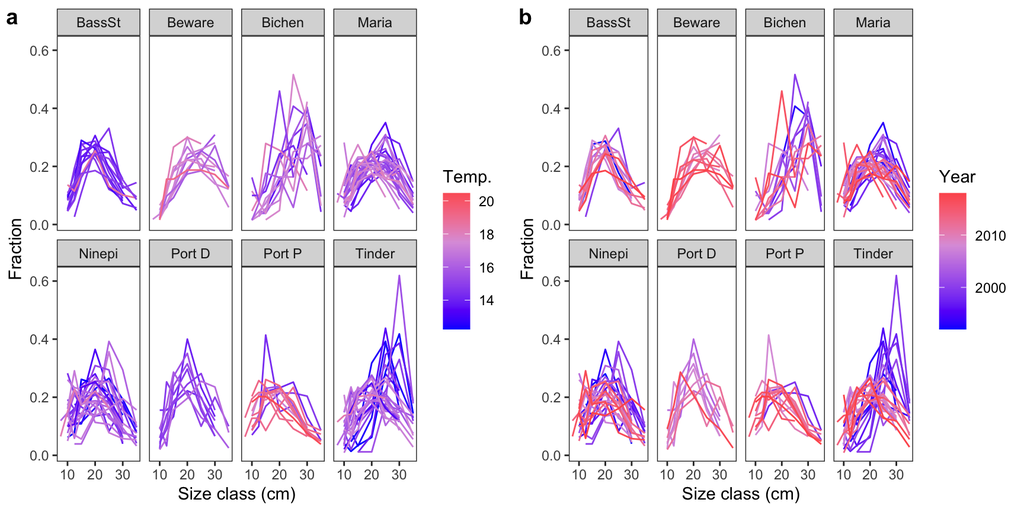

```r
pl_sst <- ggplot(df_raw) +
  geom_line(aes(x = SizeClass, y = f, group = rep, color = Esst)) +
  scale_color_gradient2(low = "blue", mid = "plum", high = "red",
    midpoint = 17.5) +
  labs(x = "Size class (cm)", y = "Fraction", color = "Temp.") +
    facet_wrap( ~ Loc, ncol = 4) +
  theme_bw() + theme(panel.grid = element_blank())

pl_year <- ggplot(df_raw) +
  geom_line(aes(x = SizeClass, y = f, group = rep, color = year)) +
  scale_color_gradient2(low = "blue", mid = "plum", high = "red",
    midpoint = 2008) +
  labs(x = "Size class (cm)", y = "Fraction", color = "Year") +
    facet_wrap( ~ Loc, ncol = 4) +
  theme_bw() + theme(panel.grid = element_blank())

plot_grid(pl_sst, pl_year, labels = c("a", "b"))
```

# Modelling

## Data Preparation

```r
# prep data for Stan fitting
X   <- 60 # age-classes
eps <- 0.01
S   <- exp(log(eps)*(1:X)/X)

size_classes <- sort(unique(df_raw$SizeClass))
SC_max <- max(size_classes)
df_raw$SizeClass <- factor(df_raw$SizeClass, levels = size_classes)

# get concensus mpa status for each location
df_mpa <- df_raw |>
  select(Loc, year, mpa) |>
  unique() |>
  arrange(Loc, year)

df_mpa_grp <- df_mpa |>
  summarise(.by = "Loc", mpa = round(mean(mpa),0))

df_fit <- df_raw |>
  arrange(SizeClass) |>
  select(Loc, year, rep, Esst, SizeClass, fish_count) |>
    left_join(df_mpa_grp, by = "Loc") |>
  pivot_wider(names_from = SizeClass, values_from = fish_count) |>
  arrange(Loc, year)

df_fit <- df_fit %>%
  mutate(across(everything(), ~ replace_na(.x, 0))) # replace all NAs with 0

N <- nrow(df_fit) # location x year data sets
J <- length(size_classes) # number of size classes
L <- rep(0, J+1)  # length-class boundaries
Lmax <- SC_max + 10 # maximum size
for (j in 2:J) {
  L[j] <- 0.5*(size_classes[j-1] + size_classes[j])
}
L[J+1] <- Lmax # final length bin

# z-transform sea-surface temperatures
Esst_E  <- mean(df_fit$Esst)
Esst_sd <- sd(df_fit$Esst)
Esst_z  <- (df_fit$Esst - Esst_E) / Esst_sd

# extract fish counts
m_n <- as.matrix(df_fit[ , 6:(5+J)]) # matrix of counts
nT <- apply(m_n, 1, sum) # total counts per set

r <- as.integer(factor(df_fit$Loc)) # location (integer)
R <- max(r)                         # number of locations

# create a list of data to pass to Stan
stan_dat <- list(
  N     = N,        # number of sets
    R     = R,        # number of locations (random effect)
  J     = J,        # number of size classes
  X     = X,        # age classes
  lnEps = log(eps), # log of epsilon
  S     = S,        # age-dependent survival
  Lmid  = size_classes, # middle of length box
  L     = L,        # length boundaries
    r     = r,        # location index
    mpa   = df_fit$mpa, # mpa status
  zT    = Esst_z,   # z-transformed sea-surface temperatures
  nT    = nT,       # total number of fish per set
  y     = m_n       # fish counts [set, sizeclass]
)

glimpse(stan_dat)
```

```
List of 13
 $ N    : int 135
 $ R    : int 8
 $ J    : int 8
 $ X    : num 60
 $ lnEps: num -4.61
 $ S    : num [1:60] 0.926 0.858 0.794 0.736 0.681 ...
 $ Lmid : num [1:8] 7.5 10 12.5 15 20 25 30 35
 $ L    : num [1:9] 0 8.75 11.25 13.75 17.5 ...
 $ r    : int [1:135] 1 1 1 1 1 1 1 1 1 1 ...
 $ mpa  : num [1:135] 0 0 0 0 0 0 0 0 0 0 ...
 $ zT   : num [1:135] -0.585 -0.637 -1.071 -0.56 -1.15 ...
 $ nT   : num [1:135] 1522 797 1411 1474 1535 ...
 $ y    : num [1:135, 1:8] 0 0 0 0 0 0 0 0 0 0 ...
  ..- attr(*, "dimnames")=List of 2
  .. ..$ : NULL
  .. ..$ : chr [1:8] "7.5" "10" "12.5" "15" ...
```

## Stan Model

```stan
data {
  int<lower=1>              N;      // number of sets
  int<lower=1>              R;      // number of locations
  int<lower=1>              J;      // number of size classes
  int<lower=1>              X;      // age-classes
  real                  lnEps;      // ln(epsilon)
  real<lower=0.001,upper=1> S[X];   // probability alive
  real<lower=0>          Lmid[J];   // length boundaries
  real<lower=0>             L[J+1]; // length boundaries
  int<lower=1,upper=R>      r[N];   // location index
  int<lower=0,upper=1>    mpa[N];   // mpa status: 0 = no, 1 = yes
  real                     zT[N];   // z-transformed sea-surface temperatures
  int<lower=1>             nT[N];   // total number of fish per set
  int<lower=0>              y[N,J]; // fish counts [set, sizeclass]
}

parameters {
  real<lower= 1.0,upper=50.00> phi;        // multinomial overdispersion parameter
  real<lower=30.00,upper=55.00> ELInf;     // expected maximum size
  real<lower= 0.50,upper= 2.50> MpK;       // typical M / K across sites and years
  real<lower=-0.50,upper= 0.50> beta_z;    // effect of temperature on M / K
  real<lower=-0.50,upper= 0.50> beta_mpa;  // effect of mpa on M / K
  real<lower= 0.00,upper=25.00> L50;       // length when 50% observed
  real<lower= 1.00,upper=20.00> DL95;      // length when 95% observed= L50+DL95
  real<lower= 0.05,upper= 0.30> cv;        // coefficient of variation in LInf
  real<lower=0.1,upper=1.00>    sigma_Loc; // between location variation
  real<lower=0.1,upper=1.00>    sigma_N;   // between year:location variation
  real MPK_Loc_RE[R];   // random deviations around overall mean for all locations
  real MPK_N_RE[N];   // random deviations around overall mean for all locations
}

transformed parameters{
}

model {
  vector[J] g;     // probability in length bin j
  vector[J] alpha; // multinomial parameter for length bin j
  vector[J] s;     // probability observe
  vector[X] Lbar;  // expected length at age

  array[J, X] real z; // z-transformed length

  real sum1;
  real sum2;
  real alpha0;
  real MpKi; // M / K for specific i

  // set priors
  phi      ~ exponential(0.1);
  ELInf    ~ normal(40.0, 10.0);
  MpK      ~ normal( 1.5,  0.5);
  beta_z   ~ normal( 0.0,  0.2);
  beta_mpa ~ normal( 0.0,  0.2);
  L50      ~ normal(15.0,  5.0);
  DL95     ~ normal(10.0,  5.0);
  cv       ~ normal( 0.1,  0.05);
  sigma_Loc ~ normal(0.0,  0.5);
  sigma_N   ~ normal(0.0,  0.5);

  MPK_Loc_RE ~ normal(0.0, sigma_Loc); // random effect deviations (vectorised)
  MPK_N_RE   ~ normal(0.0, sigma_N);

  alpha0 = 1.0 / phi; // alpha sum

  for (j in 1:J) { // probability observed when in length bin j
    s[j] = 1.0 / (1 + exp(-(log(19)/DL95)*(Lmid[j]-L50)));
  }

  for (i in 1:N) { // for each set of counts
    // set specific M /K
    MpKi = exp(log(MpK) + beta_z*zT[i] + beta_mpa*mpa[i] +
      MPK_Loc_RE[r[i]] +  MPK_N_RE[i]);

    for (x in 1:X) { // expected length at age
      Lbar[x] = ELInf*(1.0 - exp(lnEps*x/(X*MpKi)));
    }

    for (x in 1:X) {
      for (j in 1:J) { // z-transformed length-at-age
        z[j,x] = (L[j+1] - Lbar[x])/(cv*Lbar[x]);
      }
    }

    // calculate g_j for this observation i

    sum2 = 0.0; // first length box
    for (x in 1:X) {
      sum2 += S[x]*normal_cdf(z[1,x], 0, 1);
    }
    g[1] = s[1]*sum2;
    sum1 = g[1];

    for (j in 2:(J-1)) { // intermediate length boxes
      sum2 = 0.0;
      for (x in 1:X) {
        sum2 += S[x]*(normal_cdf(z[j,x], 0, 1) - normal_cdf(z[j-1,x], 0, 1));
      }
      g[j] = s[j]*sum2;
      sum1 += g[j];
    }

    sum2 = 0.0; // last length box
    for (x in 1:X) {
      sum2 += S[x]*(1.0 - normal_cdf(z[J,x], 0, 1));
    }
    g[J] = s[J]*sum2;
    sum1 += g[J];

    // calculate alpha
    for (j in 1:J) {
       g[j] = g[j] / sum1; // normalise
       alpha[j] = g[j] / alpha0; // scale probabilities to multinomial params
    }

    // calculate log-likelihood
    sum1 = lgamma(alpha0) + lgamma(nT[i] + 1) - lgamma(nT[i] + alpha0);
    for (j in 1:J) { // for each sub-period
      sum1 += lgamma(y[i,j] + alpha[j]) -
        lgamma(alpha[j]) - lgamma(y[i,j] + 1);
    }

    target += sum1; // add log-likelihood term associated with set of obs
  }
}

generated quantities {
}
```

## Model Fitting

```r
# fit the Stan model
fit_1 <- rstan::sampling(object = distribution_model, data = stan_dat,
  iter = 300, warmup = 100, chains = 1, refresh = 20)
```

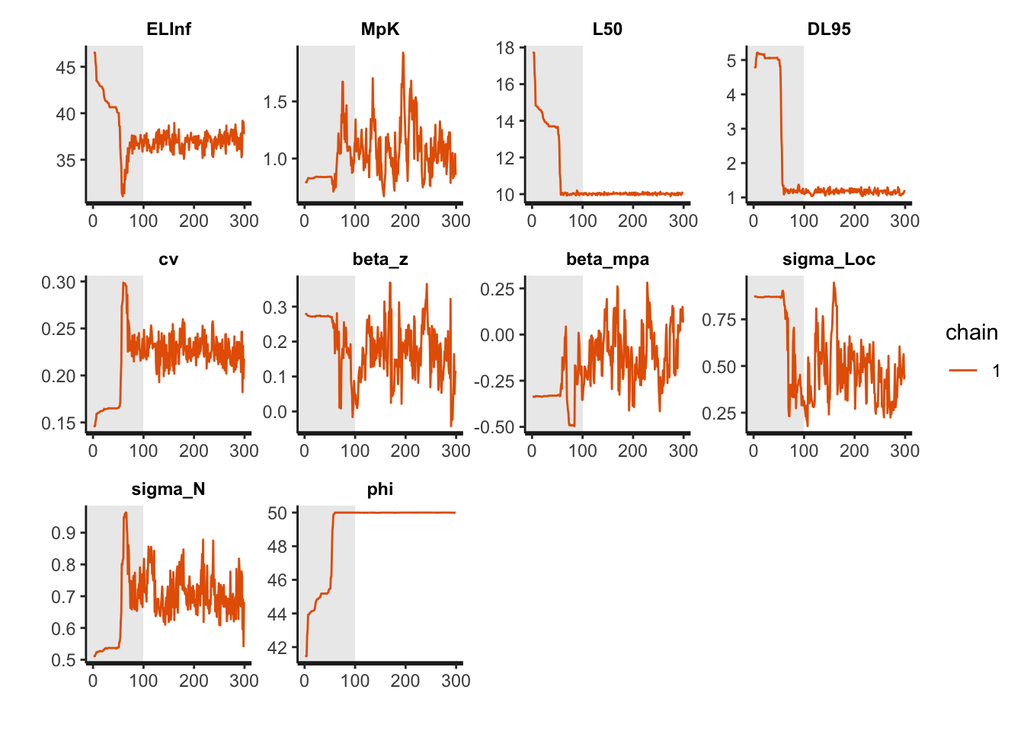

```r
# vector of model parameter names
params <- c("ELInf", "MpK", "L50", "DL95", "cv", "beta_z", "beta_mpa",
  "sigma_Loc", "sigma_N", "phi")

# check for posterior convergence
traceplot(fit_1, pars = params, inc_warmup = TRUE, ncol = 4)
```

```r
# show the posterior parameter statistics
print(fit_1, probs = c(0.055,0.5,0.945), digits=3) # 89% credible intervals
```

```
Inference for Stan model: anon_model.
1 chains, each with iter=300; warmup=100; thin=1;
post-warmup draws per chain=200, total post-warmup draws=200.

                   mean se_mean     sd      5.5%       50%     94.5% n_eff
phi              49.996   0.001  0.004    49.988    49.997    50.000    12
ELInf            37.012   0.093  0.823    35.631    37.050    38.226    78
MpK               1.096   0.046  0.231     0.786     1.058     1.520    25
beta_z            0.166   0.013  0.077     0.043     0.165     0.293    34
beta_mpa         -0.093   0.026  0.148    -0.304    -0.119     0.143    33
L50              10.015   0.003  0.044     9.945    10.017    10.085   206
DL95              1.163   0.006  0.061     1.066     1.159     1.261    99
cv                0.227   0.001  0.014     0.205     0.227     0.250   101
sigma_Loc         0.466   0.036  0.156     0.263     0.464     0.738    19
sigma_N           0.708   0.010  0.061     0.625     0.699     0.819    36
MPK_Loc_RE[1]     0.187   0.043  0.260    -0.231     0.190     0.628    38
MPK_Loc_RE[2]    -0.372   0.056  0.299    -0.894    -0.341     0.059    28
MPK_Loc_RE[3]    -0.859   0.071  0.344    -1.372    -0.849    -0.324    24
MPK_Loc_RE[4]    -0.054   0.030  0.215    -0.389    -0.062     0.328    51
MPK_Loc_RE[5]     0.270   0.043  0.239    -0.076     0.260     0.643    30
MPK_Loc_RE[6]     0.183   0.044  0.283    -0.266     0.199     0.640    41
MPK_Loc_RE[7]     0.164   0.034  0.229    -0.220     0.164     0.531    46
MPK_Loc_RE[8]    -0.180   0.036  0.242    -0.602    -0.179     0.182    45
MPK_N_RE[1]       0.328   0.027  0.260    -0.076     0.325     0.742    90
MPK_N_RE[2]      -1.144   0.034  0.256    -1.590    -1.122    -0.716    57
MPK_N_RE[3]      -0.048   0.031  0.257    -0.444    -0.038     0.358    70
MPK_N_RE[4]       0.281   0.022  0.246    -0.099     0.311     0.656   126
MPK_N_RE[5]       0.596   0.024  0.249     0.198     0.612     1.002   106
MPK_N_RE[6]       0.582   0.023  0.231     0.210     0.590     0.951   103
MPK_N_RE[7]       0.675   0.029  0.277     0.241     0.659     1.160    90
MPK_N_RE[8]       0.278   0.026  0.244    -0.094     0.275     0.662    86
MPK_N_RE[9]      -0.130   0.026  0.271    -0.535    -0.133     0.283   112
MPK_N_RE[10]      0.120   0.033  0.312    -0.373     0.131     0.622    91
MPK_N_RE[11]     -0.392   0.029  0.317    -0.868    -0.379     0.062   116
MPK_N_RE[12]     -0.562   0.026  0.296    -0.991    -0.573    -0.073   132
MPK_N_RE[13]     -0.258   0.027  0.328    -0.647    -0.268     0.249   148
MPK_N_RE[14]      0.248   0.029  0.288    -0.176     0.243     0.722    97
MPK_N_RE[15]      0.493   0.031  0.290     0.051     0.474     0.985    89
MPK_N_RE[16]      0.141   0.030  0.283    -0.290     0.133     0.592    88
MPK_N_RE[17]     -0.781   0.033  0.332    -1.299    -0.774    -0.297   102
```

[output cut: 264 more lines]

```
MPK_N_RE[127] 0.998
MPK_N_RE[128] 0.996
MPK_N_RE[129] 0.996
MPK_N_RE[130] 0.995
MPK_N_RE[131] 0.998
MPK_N_RE[132] 0.997
MPK_N_RE[133] 1.014
MPK_N_RE[134] 1.021
MPK_N_RE[135] 1.001
lp__          0.996

Samples were drawn using NUTS(diag_e) at Fri Nov 22 15:04:29 2024.
For each parameter, n_eff is a crude measure of effective sample size,
and Rhat is the potential scale reduction factor on split chains (at
convergence, Rhat=1).
```

```r
l_pars <- extract(fit_1) # extract posterior samples
```

# Predictions

## M/K and $L_\infty$

```r
df_MpK <- tibble(
    Esst = seq(from = min(df_fit$Esst), to = max(df_fit$Esst),
      length.out = 20)
  ) |>
  mutate(
    zT = (Esst - Esst_E) / Esst_sd,
    MpK_mdn = 0, MpK_lwr = 0, MpK_upr = 0) # median, lower

for (i in 1:nrow(df_MpK)) {
  MpK <- exp(log(l_pars$MpK) + l_pars$beta_z*df_MpK$zT[i])
  df_MpK$MpK_mdn[i] <- median(MpK)
  df_MpK$MpK_lwr[i] <- quantile(MpK, probs = 0.05)
  df_MpK$MpK_upr[i] <- quantile(MpK, probs = 0.95)
}

df_s <- tibble(
    Lmid = size_classes
  ) |>
  mutate(
    s_mdn = 0, s_lwr = 0, s_upr = 0) # median, lower

for (i in 1:nrow(df_s)) {
  s <- 1.0 / (1 + exp(-(log(19)/l_pars$DL95)*(df_s$Lmid[i]-l_pars$L50)));

  df_s$s_mdn[i] <- median(s)
  df_s$s_lwr[i] <- quantile(s, probs = 0.05)
  df_s$s_upr[i] <- quantile(s, probs = 0.95)
}

df_ELInf <- tibble(ELInf = l_pars$ELInf)

df_cv <- tibble(cv = l_pars$cv)
```

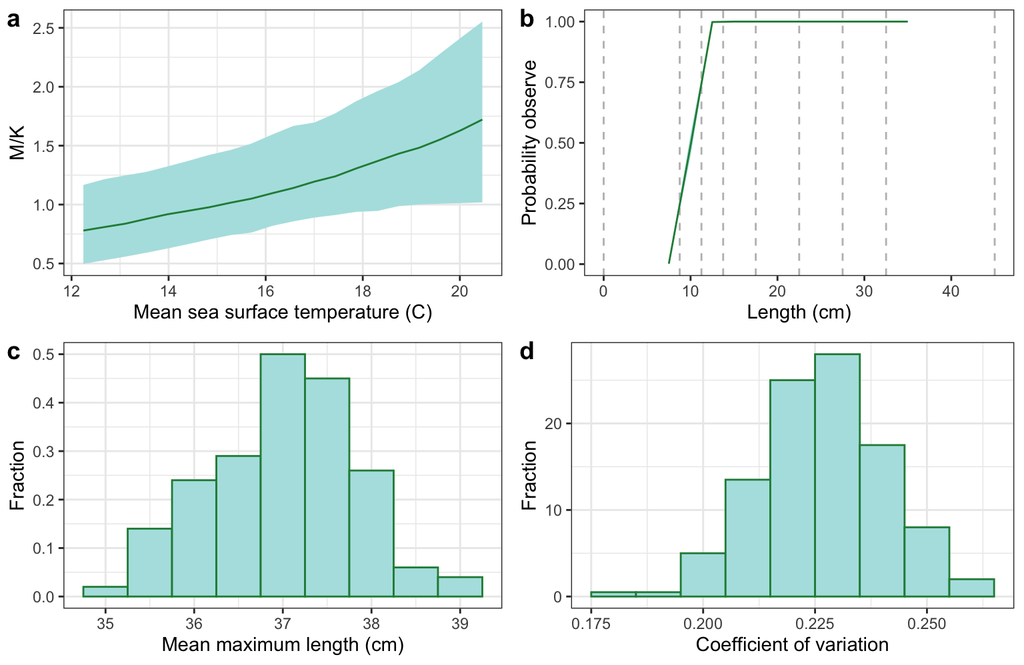

Figure 1: Posterior predictions. (a) Effect of sea surface temperature on M/K at unprotected locations. (b) Length-dependent probability of detection. (c) Mean maximum length. (d) Coefficient of variation of fish lengths for a given age. Shaded regions depict 90% credible intervals.

```r
pl_MpK <- ggplot(df_MpK) +
  geom_ribbon(aes(x = Esst, ymin = MpK_lwr, ymax = MpK_upr), fill = "#b2e2e2") +
  geom_line(aes(x = Esst, y = MpK_mdn), color = "#238b45") +
  labs(x = "Mean sea surface temperature (C)", y = "M/K") +
  theme_bw()

pl_s <- ggplot(df_s) +
  geom_vline(xintercept = L, linetype = "dashed", color = "grey") +
  geom_ribbon(aes(x = Lmid, ymin = s_lwr, ymax = s_upr), fill = "#b2e2e2") +
  geom_line(aes(x = Lmid, y = s_mdn), color = "#238b45") +
  labs(x = "Length (cm)", y = "Probability observe") +
  theme_bw() + theme(panel.grid = element_blank())

pl_ELInf <- ggplot(df_ELInf) +
  geom_histogram(aes(x = ELInf, y = after_stat(density)),
    binwidth = 0.5, fill = "#b2e2e2", color = "#238b45") +
  labs(x = "Mean maximum length (cm)", y = "Fraction") +
  theme_bw()

pl_cv <- ggplot(df_cv) +
  geom_histogram(aes(x = cv, y = after_stat(density)),
    binwidth = 0.01, fill = "#b2e2e2", color = "#238b45") +
  labs(x = "Coefficient of variation", y = "Fraction") +
  theme_bw()

plot_grid(pl_MpK, pl_s, pl_ELInf, pl_cv, labels = c("a", "b", "c", "d"))
```

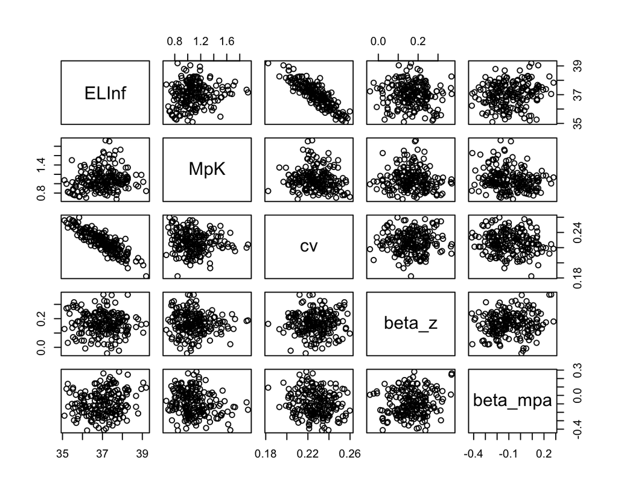

Figure 2: Posterior parameter correlations.

```r
pairs(as.data.frame(l_pars) |> select(ELInf, MpK, cv, beta_z, beta_mpa))
```

## Size Distribution

```r
REPS  <- length(l_pars$phi)
eps   <- 0.005 # upper survival
lnEps <- log(eps)

Essts <- c(13, 16, 19)
zT <- (Essts - Esst_E) / Esst_sd
```

```r
# predict for a typical location
N_predict <- length(Essts)

m_g_mdn <- matrix(data = NA, nrow = N_predict, ncol = J)
m_g_lwr <- matrix(data = NA, nrow = N_predict, ncol = J)
m_g_upr <- matrix(data = NA, nrow = N_predict, ncol = J)

Lbar <- matrix(data = NA, nrow = REPS, ncol = X)
z    <- array(data = NA, dim = c(REPS, J, X))

alpha0 = 1.0 / l_pars$phi # alpha sum
s   <- matrix(data = NA, nrow = REPS, ncol = J)
for (j in 1:J) { # probability observed when in length bin j
  s[ ,j] = 1.0 / (1 + exp(-(log(19)/l_pars$DL95)*(size_classes[j]-l_pars$L50)))
}

for (n in 1:N_predict) {
  g    <- matrix(data = 0, nrow = REPS, ncol = J)
  MpKi <- exp(log(l_pars$MpK) + l_pars$beta_z*zT[n]) # set specific M /K

  for (x in 1:X) { # expected length at age
    Lbar[ ,x] <- l_pars$ELInf*(1.0 - exp(lnEps*x/(X*MpKi)))
  }

  for (x in 1:X) {
    for (j in 1:J) { # z-transformed length-at-age
      z[ ,j,x] = (L[j+1] - Lbar[ ,x])/(l_pars$cv*Lbar[ ,x])
    }
  }

  # calculate g_j for this prediction

  sum1 <- rep(0, REPS)

  sum2 <- rep(0, REPS)
  for (x in 1:X) {
    sum2 <- sum2 + S[x]*pnorm(z[ ,1,x])
  }
  g[ ,1] = s[ ,1]*sum2
  sum1 = g[ ,1]

  for (j in 2:(J-1)) { # intermediate length boxes
    sum2 <- rep(0, REPS)
    for (x in 1:X) {
      sum2 <- sum2 +  S[x]*(pnorm(z[ ,j,x]) - pnorm(z[ ,j-1,x]))
    }
    g[ ,j] = s[ ,j]*sum2
    sum1 <- sum1 + g[ ,j]
  }

  sum2 <- rep(0, REPS) # last length box
  for (x in 1:X) {
    sum2 <- sum2 + S[x]*(1.0 - pnorm(z[ ,J,x]))
  }
  g[ ,J] = s[ ,J]*sum2
  sum1 <- sum1 + g[ ,J]

  # calculate g
  for (j in 1:J) {
    g[ ,j] = g[ ,j] / sum1 # normalise
  }

  m_g_mdn[n, ] <- apply(X = g, MARGIN = 2, FUN = median)
  m_g_lwr[n, ] <- apply(X = g, MARGIN = 2, FUN = quantile, probs = 0.05)
  m_g_upr[n, ] <- apply(X = g, MARGIN = 2, FUN = quantile, probs = 0.95)
}

df_g <- tibble(
  Lmid = size_classes,
  Esst = Essts[1],
  g_lwr = m_g_lwr[1, ],
  g_mdn = m_g_mdn[1, ],
  g_upr = m_g_upr[1, ])

for (n in 2:N_predict) {
  df_g <- df_g |>
    rbind(tibble(
      Lmid = size_classes,
      Esst = Essts[n],
      g_lwr = m_g_lwr[n, ],
      g_mdn = m_g_mdn[n, ],
      g_upr = m_g_upr[n, ]))
}

df_g$EsstF <- factor(df_g$Esst)
```

```r
# predict for the observed locations
Locs <- sort(unique(df_fit$Loc))
df_gLoc <- expand_grid(Loc = Locs, Esst = Essts) |>
  left_join(df_mpa_grp, by = "Loc")
df_gLoc$Loc <- factor(df_gLoc$Loc)
df_gLoc$iLoc <- as.integer(df_gLoc$Loc)
df_gLoc$iEsst <- as.integer(factor(df_gLoc$Esst))


N_predict <- nrow(df_gLoc)

m_gLoc_mdn <- matrix(data = NA, nrow = N_predict, ncol = J)
m_gLoc_lwr <- matrix(data = NA, nrow = N_predict, ncol = J)
m_gLoc_upr <- matrix(data = NA, nrow = N_predict, ncol = J)

Lbar <- matrix(data = NA, nrow = REPS, ncol = X)
z    <- array(data = NA, dim = c(REPS, J, X))

alpha0 = 1.0 / l_pars$phi # alpha sum
s   <- matrix(data = NA, nrow = REPS, ncol = J)
for (j in 1:J) { # probability observed when in length bin j
  s[ ,j] = 1.0 / (1 + exp(-(log(19)/l_pars$DL95)*(size_classes[j]-l_pars$L50)))
}

for (n in 1:N_predict) {
  g    <- matrix(data = 0, nrow = REPS, ncol = J)
  MpKi <- exp(log(l_pars$MpK) +
    l_pars$beta_z*zT[df_gLoc$iEsst[n]] + l_pars$beta_mpa*df_gLoc$iEsst[n] +
    l_pars$MPK_Loc_RE[ ,df_gLoc$iLoc[n]]) # set specific M /K

  for (x in 1:X) { # expected length at age
    Lbar[ ,x] <- l_pars$ELInf*(1.0 - exp(lnEps*x/(X*MpKi)))
  }

  for (x in 1:X) {
    for (j in 1:J) { # z-transformed length-at-age
      z[ ,j,x] = (L[j+1] - Lbar[ ,x])/(l_pars$cv*Lbar[ ,x])
    }
  }

  # calculate g_j for this prediction

  sum1 <- rep(0, REPS)

  sum2 <- rep(0, REPS)
  for (x in 1:X) {
    sum2 <- sum2 + S[x]*pnorm(z[ ,1,x])
  }
  g[ ,1] = s[ ,1]*sum2
  sum1 = g[ ,1]

  for (j in 2:(J-1)) { # intermediate length boxes
    sum2 <- rep(0, REPS)
    for (x in 1:X) {
      sum2 <- sum2 +  S[x]*(pnorm(z[ ,j,x]) - pnorm(z[ ,j-1,x]))
    }
    g[ ,j] = s[ ,j]*sum2
    sum1 <- sum1 + g[ ,j]
  }

  sum2 <- rep(0, REPS) # last length box
  for (x in 1:X) {
    sum2 <- sum2 + S[x]*(1.0 - pnorm(z[ ,J,x]))
  }
  g[ ,J] = s[ ,J]*sum2
  sum1 <- sum1 + g[ ,J]

  # calculate g
  for (j in 1:J) {
    g[ ,j] = g[ ,j] / sum1 # normalise
  }

  m_gLoc_mdn[n, ] <- apply(X = g, MARGIN = 2, FUN = median)
  m_gLoc_lwr[n, ] <- apply(X = g, MARGIN = 2, FUN = quantile, probs = 0.05)
  m_gLoc_upr[n, ] <- apply(X = g, MARGIN = 2, FUN = quantile, probs = 0.95)
}

df_gLocL <- tibble(
    Loc = df_gLoc$Loc[1],
  Lmid = size_classes,
  Esst = df_gLoc$Esst[1],
  g_lwr = m_gLoc_lwr[1, ],
  g_mdn = m_gLoc_mdn[1, ],
  g_upr = m_gLoc_upr[1, ])

for (n in 2:N_predict) {
  df_gLocL <- df_gLocL |>
    rbind(tibble(
        Loc = df_gLoc$Loc[n],
      Lmid = size_classes,
      Esst = df_gLoc$Esst[n],
      g_lwr = m_gLoc_lwr[n, ],
      g_mdn = m_gLoc_mdn[n, ],
      g_upr = m_gLoc_upr[n, ]))
}

df_gLocL$EsstF <- factor(df_gLocL$Esst)
```

```r
# observed frequencies
m_f <- m_n
for(n in 1:N) {
  m_f[n, ] <- m_n[n, ] / nT[n]
}

df_f <- tibble(rep = 1:N, Loc = df_fit$Loc, Esst = Esst_z*Esst_sd + Esst_E) |>
  cbind(as.data.frame(m_f)) |>
  pivot_longer(names_to = "Lmid", values_to = "f",
    cols = all_of(4:(3+J)), names_transform = as.numeric)

df_f <- df_f |>
  mutate(
    EsstF = ifelse(Esst < 0.5*(Essts[1] + Essts[2]), Essts[1],
      ifelse(Esst > 0.5*(Essts[2] + Essts[3]), Essts[3], Essts[2])))
df_f$EsstF <- factor(df_f$EsstF)
```

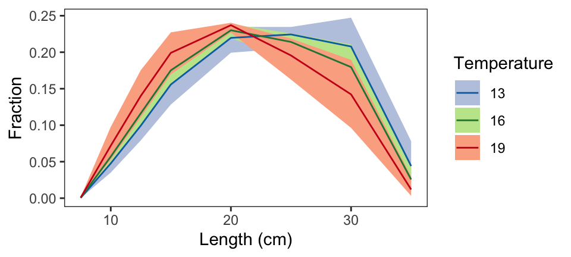

Figure 3: Predicted fish length distributions for three sea surface temperatures, for locations not an mpa. Shaded regions depict 90% credible intervals.

```r
ggplot() +
  geom_ribbon(data = df_g,
    aes(x = Lmid, ymin = g_lwr, ymax = g_upr, fill = EsstF)) +
  geom_line(data = df_g, aes(x = Lmid, y = g_mdn, color = EsstF)) +
  scale_color_manual(values = c("#0570b0", "#238443", "#cb181d")) +
  scale_fill_manual(values = c("#bdc9e1", "#c2e699", "#fcae91")) +
  labs(x = "Length (cm)", y = "Fraction",
    color = "Temperature", fill = "Temperature") +
  theme_bw() + theme(panel.grid = element_blank())
```

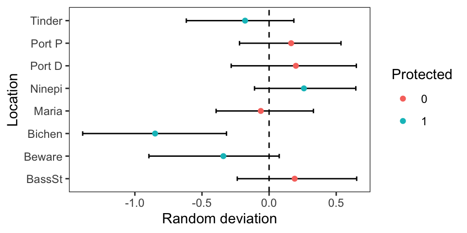

Figure 4: Random deviations in log(M/K) associated with the eight locations. Error bars depict the 90% credible interval.

```r
df_Loc <- t(apply(X = l_pars$MPK_Loc_RE, MARGIN = 2, FUN = quantile, probs = c(0.05, 0.5, 0.95))) |>
  as_tibble()
names(df_Loc) <- c("lwr", "mdn", "upr")
df_Loc$Loc <- levels(factor(df_fit$Loc))

df_Loc <- df_Loc |>
  left_join(df_mpa_grp, by = "Loc")
df_Loc$mpa <- factor(df_Loc$mpa)

ggplot(df_Loc) +
  geom_vline(xintercept = 0, linetype = "dashed") +
  geom_errorbarh(aes(xmin = lwr, xmax = upr, y = Loc), height = 0.2) +
  geom_point(aes(x = mdn, y = Loc, color = mpa)) +
    labs(x = "Random deviation", y = "Location", color = "Protected") +
  theme_bw() + theme(panel.grid = element_blank())
```

```r
df_N <- t(apply(X = l_pars$MPK_N_RE, MARGIN = 2, FUN = quantile, probs = c(0.05, 0.5, 0.95))) |>
  as_tibble()
names(df_N) <- c("lwr", "mdn", "upr")
df_N$Loc <- df_fit$Loc
df_N$year <- df_fit$year

df_N <- df_N |>
  left_join(df_mpa, by = c("Loc", "year"))
df_N$mpa <- factor(df_N$mpa)
```

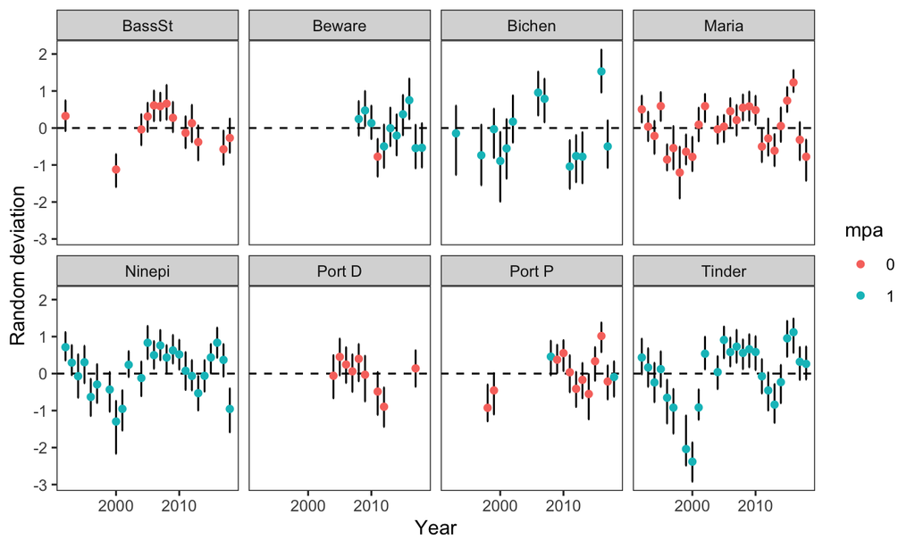

Figure 5: Random deviations in log(M/K) associated with the 135 location x year combinations. Error bars depict the 90% credible interval.

```r
ggplot(df_N) +
  geom_hline(yintercept = 0, linetype = "dashed") +
  geom_errorbar(aes(ymin = lwr, ymax = upr, x = year), width = 0.2) +
  geom_point(aes(y = mdn, x = year, color = mpa)) +
    facet_wrap( ~ Loc, ncol = 4) +
    labs(x = "Year", y = "Random deviation") +
  theme_bw() + theme(panel.grid = element_blank())
```

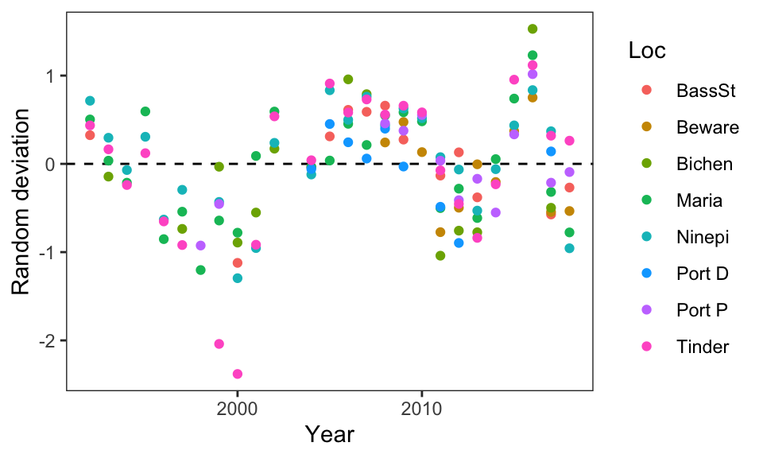

```r
ggplot(df_N) +
  geom_hline(yintercept = 0, linetype = "dashed") +
  geom_point(aes(y = mdn, x = year, color = Loc)) +
    labs(x = "Year", y = "Random deviation") +
  theme_bw() + theme(panel.grid = element_blank())
```

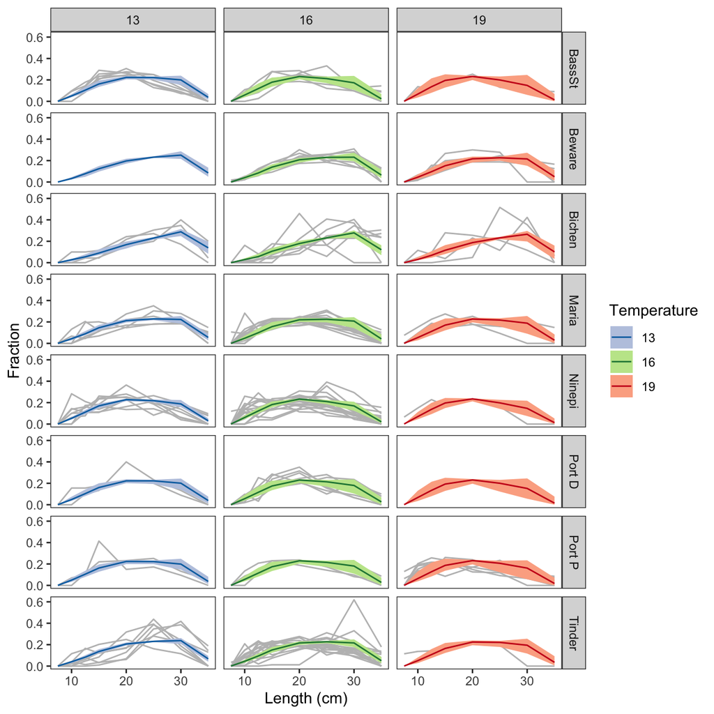

Figure 7: Predicted fish length distributions for three sea surface temperatures in relation to observed length distributions at each sampling location. Shaded regions depict 90% credible intervals.

```r
ggplot() +
  geom_line(data = df_f, aes(x = Lmid, y = f, group = rep),
    color = "grey") +
  geom_ribbon(data = df_gLocL,
    aes(x = Lmid, ymin = g_lwr, ymax = g_upr, fill = EsstF)) +
  geom_line(data = df_gLocL, aes(x = Lmid, y = g_mdn, color = EsstF)) +
  scale_color_manual(values = c("#0570b0", "#238443", "#cb181d")) +
  scale_fill_manual(values = c("#bdc9e1", "#c2e699", "#fcae91")) +
  facet_grid(Loc ~ EsstF) +
  labs(x = "Length (cm)", y = "Fraction",
    color = "Temperature", fill = "Temperature") +
  theme_bw() + theme(panel.grid = element_blank())
```

# Conclusions

## Minor

- Wide bin widths are making observation selectivity tricky to estimate (Figure 1 b)
  - how good is the numerical approximation that selectivity holds equally across the length bin?
- fit wants to lower $\bar{L}_\infty$ and increase the coefficient of variation (CoV) (Figure 2)
  - how strong to make priors on CoV (Figure 1 d)?
- There is so much variation in the frequencies between length bins, that it cannot be all explained by the Dirichelet multinomial distribution
  - $\phi$ is estimated to be high (> 20) and has little additional effect on fit when increased further
  - suggests that the model is structurally inadequate in some way
    - missing predictors?